# 6_Predicting numerical data - regression methods

### ステップ3：モデルを訓練する

回帰木モデルを訓練する。回帰木モデルの構築には決定木のほぼすべての実装を利用できるが、CARTチームが定義した回帰木を最も忠実に実装しているのはrpartパッケージである。

```r
# ライブラリの読み込み
if(! require(rpart)){
    install.packages('rpart', quiet = TRUE)
}
library(rpart)
```

```r
m.rpart
```

```
n= 3750

node), split, n, deviance, yval
      * denotes terminal node

 1) root 3750 2945.53200 5.870933
   2) alcohol< 10.85 2372 1418.86100 5.604975
     4) volatile.acidity>=0.2275 1611  821.30730 5.432030
       8) volatile.acidity>=0.3025 688  278.97670 5.255814 *
       9) volatile.acidity< 0.3025 923  505.04230 5.563380 *
     5) volatile.acidity< 0.2275 761  447.36400 5.971091 *
   3) alcohol>=10.85 1378 1070.08200 6.328737
     6) free.sulfur.dioxide< 10.5 84   95.55952 5.369048 *
     7) free.sulfur.dioxide>=10.5 1294  892.13600 6.391036
      14) alcohol< 11.76667 629  430.11130 6.173291
        28) volatile.acidity>=0.465 11   10.72727 4.545455 *
        29) volatile.acidity< 0.465 618  389.71680 6.202265 *
      15) alcohol>=11.76667 665  403.99400 6.596992 *
```

回帰木のノードごとに、決定ノードに到達したインスタンスの個数が出力されている。たとえば、ルートノードから出発した3,750個のインスタンスのうち、2,372個がalchol < 10.85に分類されており、1,378個がalcohol >= 10.85に分類されている。 alcoholは、この回帰木で最初に使われた独立変数なので、ワインの品質にとって最も重要な説明変数はアルコール度数ということになる。

*がついているノードは葉（終端）ノードであり、そこで予測値（yval）が生成されることを意味する。たとえば、ノード5のyvalは5.971091である。したがって、この回帰木を使って予測を行うとしたら、alcohol < 10.85かつvolatile.acidity < 0.2275のインスタンスのqualityは5.97と予測されることになる。

なお、各ノードの平均二乗誤差や特徴量の全体的な重要度など、回帰木の適合度に関するより詳細な要約統計量は、summary（m.rpart）コマンドを使って取得できる。

#### 回帰木を可視化する

この回帰木は先ほどの出力だけでも十分に理解できるが、可視化を使ったほうが理解しやすいことが多い。rpart.plotパッケージは、高品質な決定木を出力する使いやすい関数を提供する。

```r
# ライブラリの読み込み
if(! require(rpart.plot)){
    install.packages('rpart.plot', quiet = TRUE)
}
library(rpart.plot)
```

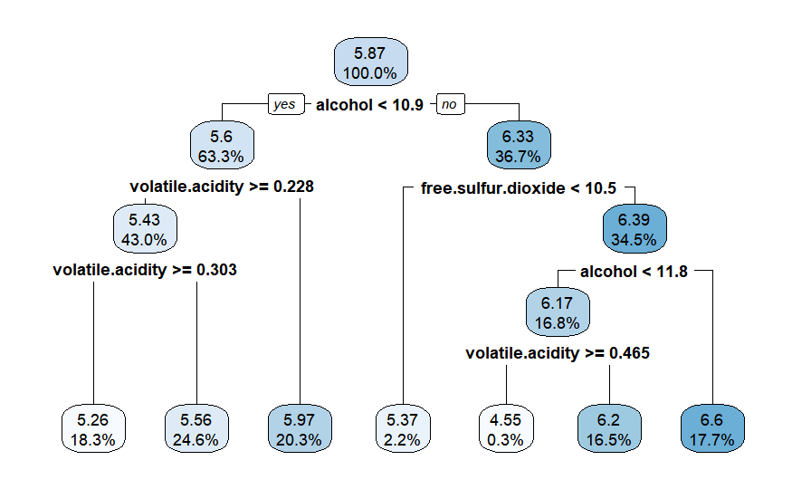

決定木図に表示される数値の桁数を制御するdigitsパラメータの他にも、可視化の様々な部分を調整できる。

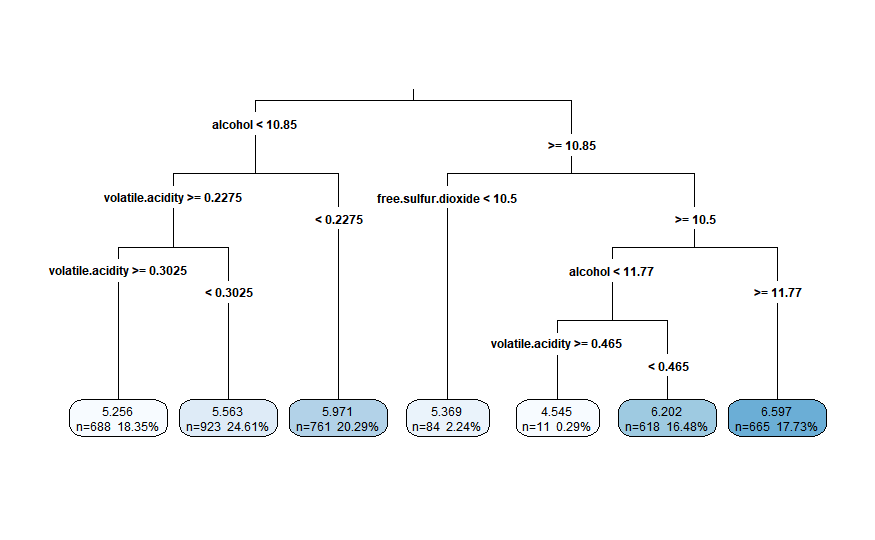

### ステップ4：モデルの性能を評価する

```r
summary(p.rpart)
```

```
   Min. 1st Qu.  Median    Mean 3rd Qu.    Max.
  4.545   5.563   5.971   5.893   6.202   6.597
```

```r
summary(wine_test$quality)
```

```
   Min. 1st Qu.  Median    Mean 3rd Qu.    Max.
  3.000   5.000   6.000   5.901   6.000   9.000
```

このモデルあh、たとえば最も評価の高いワインといった極端なケースをうまく特定できないようである。一方で、第1四分位数と 第3四分位数の間はうまく予測できているようだ。

予測値と正解値の相関は、モデルの性能を測る単純な手段となる。corかんすうをりようすれあ、同じ長さの2つのベクトル間の関係を 数値化できることを思い出そう。この関数を使って予測値が正解値にどれくらい対応しているのかを調べてみよう。

```r
cor(p.rpart, wine_test$quality)
```

```
[1] 0.5369525
```

0.54という相関は、確かに受け入れられない数字ではない。しかし、相関からわかるのは予測値と正解値の関係の強さだけで、 予測値が正解地からどれくらい離れているのかはわからない。

#### 平均絶対誤差を使って性能を評価する

モデルの性能について検討するもう１つの方法は、平均すると、予測値が正解値からどれくらい離れているのかを調べること である。今指標は**平均絶対誤差**（mean absolute error: MAE）と呼ばれる。MAEの式は次のようになる。ここで、$ｎ$は予測値 の個数を表し、$e_i$は予測値$i$の誤差を表す。

$$MAE=\frac{1}{n}\sum_{i=1}^{n}{|e_i|}$$

MAEという名前からもわかるように、この式は誤差の絶対値の平均を求めている。誤差は単に予測値と平均値の差であるため、 単純なMAE関数を次のように作成できる。

```r
MAE <- function(actual, predicted){
  mean(abs(actual - predicted))
}
```

これで、予測値のMAEを次のコマンドで取得できる。

```r
MAE(p.rpart, wine_test$quality)
```

```
[1] 0.5872652
```

つまり、モデルの予測値と正解値（実際のスコア）の差は、平均すると約0.59である。 品質の尺度は0から10であるため、このモデルの性能はかなり良いようだ。

一方で、ほとんどのワインが特によいわけでも悪いわけでもないことを思い出そう。一般的な品質スコアは 5～6である。したがって、この指標に従うと、平均値しか予測しない分類器であってもかなり性能がよいことに なってしまう。

訓練データセットでの品質スカの平均値を見てみよう。

```r
mean(wine_train$quality)
```

```
[1] 5.870933
```

全てのワインサンプルで5.87を予測したとすれば、MAEは約0.67になるはずだ。

```r
MAE(5.87, wine_test$quality)
```

```
[1] 0.6722474
```

平均すると、この回帰木（MAE = 0.59）は平均値しか予測しない分類器（MAE = 0.67） よりは正解値に近いが、たいした差ではない。Cortezのちょうさでは、ニューラルネットワークモデルのMAEは0.58、 サポートベクトルマシンのMAEは0.45である。このことは、まだ改善の余地があることを示している。

### ステップ5：モデルの性能を向上させる